# Wine

Solomon Sapio, Joseph Tseytlin, Nick Bottiglieri

5/11/2019

Introduction:

Hello and welcome to our wine data analysis! It is important to understand how to manipulate and analyze data - wine data in this case. It is important because we can learn information from these massive data sets that can help companies or individuals solve problems and predict future markets and business opportunities. Our wine data analysis will provide interested readers with new insights to make them more knowledgeable about the wine market.

Before beginning any data analysis, it is imperative for you to load all of the packages you plan to use. The tidyverse package includes many other r packages that are commonly used such a ggplot and dplyr. We will use Leaflet as well when we create a map later on.

The first step in the data curation process is to actually get the data. Kaggle is a great resource for datasets and is where we procured this dataset. It is also possible to scrape datasets from the web, and this dataset was originally made from scrapped data of wine reviews from https://www.winemag.com/. Once you find a dataset you like, download the CSV and put it in your project folder. Once you have done this you can load it using the read.csv command used below.

```r
winedata = read.csv("winemag-data-130k-v2.csv")
```

Lets explore our data set. Our data set consists of over 100,000 wine reviews with attributes such as country, region, rating, and price. To display the entire data set, simply type the name of your data set, which in our case is winedata. We will be using syntactical sugar available from the dplyr package. This allows us to use piping by doing “%>%” and includes many of the operations we will be using later such as select and filter. For more information on the dplyr package and its features you can refer to the documentation at https://www.rdocumentation.org/packages/dplyr/versions/0.7.8 The code below prints the first few elements of our dataset.

```r
 winedata %>%
  head()
```

```
##   X  country
## 1 0    Italy
## 2 1 Portugal
## 3 2       US
## 4 3       US
## 5 4       US
## 6 5    Spain
##                                                                                                                                                                                                                                                             description
## 1                                                                                          Aromas include tropical fruit, broom, brimstone and dried herb. The palate isn't overly expressive, offering unripened apple, citrus and dried sage alongside brisk acidity.
## 2                                   This is ripe and fruity, a wine that is smooth while still structured. Firm tannins are filled out with juicy red berry fruits and freshened with acidity. It's  already drinkable, although it will certainly be better from 2016.
## 3                                                                            Tart and snappy, the flavors of lime flesh and rind dominate. Some green pineapple pokes through, with crisp acidity underscoring the flavors. The wine was all stainless-steel fermented.
## 4                                                               Pineapple rind, lemon pith and orange blossom start off the aromas. The palate is a bit more opulent, with notes of honey-drizzled guava and mango giving way to a slightly astringent, semidry finish.
## 5             Much like the regular bottling from 2012, this comes across as rather rough and tannic, with rustic, earthy, herbal characteristics. Nonetheless, if you think of it as a pleasantly unfussy country wine, it's a good companion to a hearty winter stew.
## 6 Blackberry and raspberry aromas show a typical Navarran whiff of green herbs and, in this case, horseradish. In the mouth, this is fairly full bodied, with tomatoey acidity. Spicy, herbal flavors complement dark plum fruit, while the finish is fresh but grabby.
##                          designation points price          province
```

[output cut: 34 more lines]

We notice that our dataset has some unwanted information, which we remove with select.

```r
winedata = winedata %>%
  select(-taster_twitter_handle) %>%
  select(-description)
```

Lets take a look at the distribution of wine ratings (rated from 80 to 100). We use group_by and summarize to count the number of wines for each rating value.

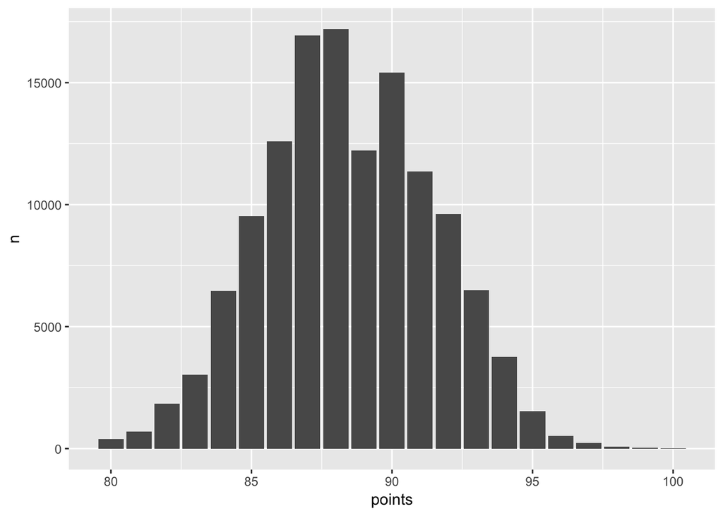

```r
winedata %>%
  group_by(points) %>%
  summarize(n = n()) %>%
  ggplot(mapping=aes(x=points, y=n)) +
    geom_bar(stat="identity")
```

What if we want to display only wine reviews from a certain country or a certain province? We can filter our dataset based on attribute values. We can then select certain attributes using the select keyword. Below is an example of filtering our dataset by country (only selecting reviews where the country of origin is Spain) and by points (where the number of points are >90). We then use the select keyword to select only certain attributes to display. Since we filtered based on country and points we will select those attributes as well as identifying attributes to display.

```r
winedata %>%
  filter(country == "Spain") %>%
  filter(points > 90) %>%
  select(country, points, variety, winery) %>%
  head()
```

```
##   country points           variety              winery
## 1   Spain     91          Graciano   Marques de Griñon
## 2   Spain     92 Carignan-Grenache             Acústic
## 3   Spain     93       Tempranillo             Resalte
## 4   Spain     92             Viura Marqués de Murrieta
## 5   Spain     92       Tempranillo    Bodegas Riojanas
## 6   Spain     91         Red Blend        Cellers Unió
```

Let’s start summarizing our dataset in order to get more useful information we can use for data analysis. We are going to need to extract the year from the “title” column in the data set in order to use it with our summarization and plotting. First, we use str_extract to extract the year using regular expressions from the title. https://www.rdocumentation.org/packages/stringr/versions/1.4.0/topics/str_extract is a link to the documentation on the extract method. In the same line we create a new column, year, to store the extracted string. Next, we need to convert the year, which is still a string, to an integer, so we use type_convert. https://www.rdocumentation.org/packages/utils/versions/3.6.0/topics/type.convert is a link to read more on type convert. Next, we filter out all of the NA values and then finally summarize the price and points columns in order to make an average of them - we will be using this average later in our graphs.

```r
winedata <- winedata %>%
  mutate(year = str_extract(title, "(\\d){4}"))

winedata <- winedata %>%
  type_convert(col_types = cols(year = col_integer())) %>%
  filter(year > 0, year < 2020, price > 0)

winedata <- winedata %>%
  group_by(variety, year, winery, province, region_1, country) %>%
  summarize(avg_price = mean(price), avg_rating = mean(points))

winedata %>%
  head()
```

```
## # A tibble: 6 x 8
## # Groups:   variety, year, winery, province, region_1 [6]
##   variety   year winery   province  region_1   country avg_price avg_rating
##   <fct>    <int> <fct>    <fct>     <fct>      <fct>       <dbl>      <dbl>
## 1 ""        1999 Carmen   Maipo Va… ""         Chile          17         88
## 2 Abouriou  2012 Cave du… Southwes… Côtes du … France         15         87
## 3 Abouriou  2012 Cerridw… Californ… Russian R… US             75         85
## 4 Abouriou  2014 Lionel … Southwes… Côtes du … France         15         91
## 5 Agiorgi…  2003 Papaioa… Nemea     ""         Greece         26         88
## 6 Agiorgi…  2003 Tsantali Nemea     ""         Greece         16         87
```

Now, we are going to plot some data to learn some things about our dataset. First, we need to include the ggplot2 library to use some of the ggplot methods. Then, we are going to create a new column for the ratio between the average rating and the average price for each wine. This ratio will be higher if the wine is rated high and is cheap and it will be lower if the wine is rated low and expensive. Overall, the more efficient wine will be rated higher. Next, we start the wine plot by grouping by country, summarizing the average rating to price ratio for each country, and summarizing the total number of wines for each country. We find the total number of wines in order to remove any countries that have less than 50 wine reviews. This is because some countries, like Ukraine, only have a small number of reviews and become an outlier in the graph. Lastly, we need to plot the data as a bar graph using ggplot. By looking at the graph, we can see that Romania has the best rating to price ratio and Canada has the lowest ratio.

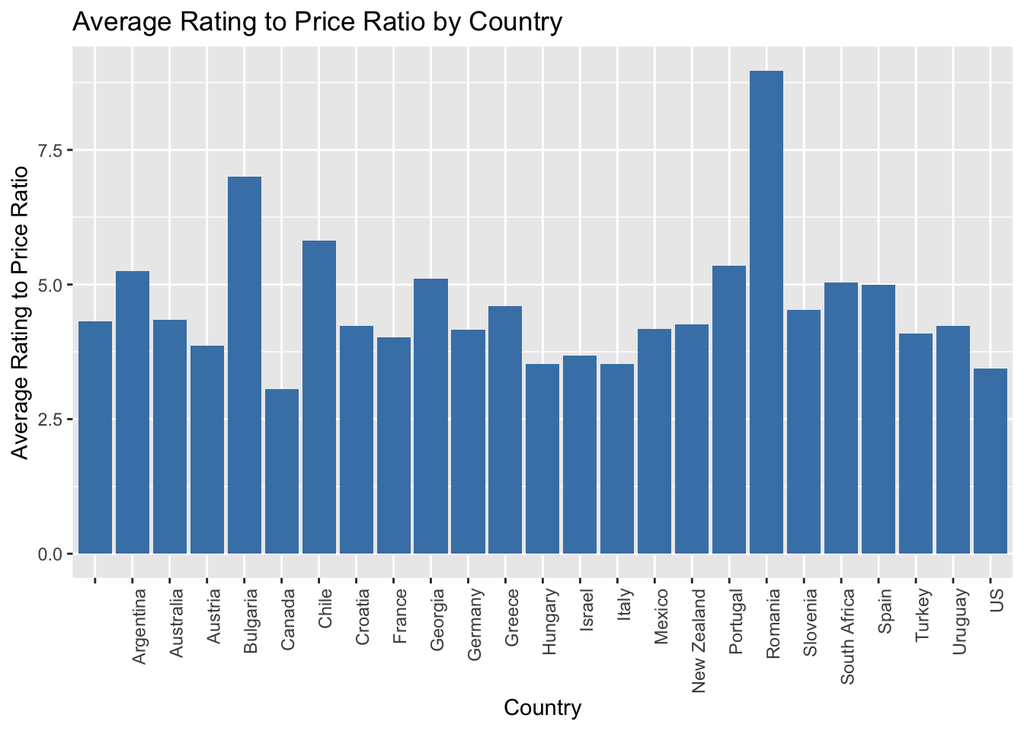

```r
library(ggplot2)

winedata <- winedata %>%
  mutate(ratingpriceratio = avg_rating/avg_price)

wineplot <- winedata %>%
  group_by(country) %>%
  summarize(avg_ratingpriceratio = mean(ratingpriceratio), wine_count = n()) %>%
  filter(wine_count > 50) %>%
  ggplot(mapping = aes(x = country, y = avg_ratingpriceratio)) +
  geom_bar(stat = "identity", fill = "steelblue") +
  theme(axis.text.x = element_text(angle = 90, hjust = 1)) +
   labs(title="Average Rating to Price Ratio by Country",
         x = "Country",
         y = "Average Rating to Price Ratio")

wineplot
```

We can pose the question of whether the rating affects the price of the wine. We assume expensive wine would rank higher than inexpensive wine, but we can plot some linear regression lines ourselves to see the difference. First, we only use countries with a significant amount of data collected for them - in this case, Chile, France, Italy, Spain, and the US have an abundance of wine data that will lead to an indisputable conclusion. Next, after filtering, we can plot the average price over the average rating of each wine. We then use a facet grid which creates a separate plot for each country. Lastly, we can add geom_smooth(method = lm) to create a line of best fit for our data for each country.

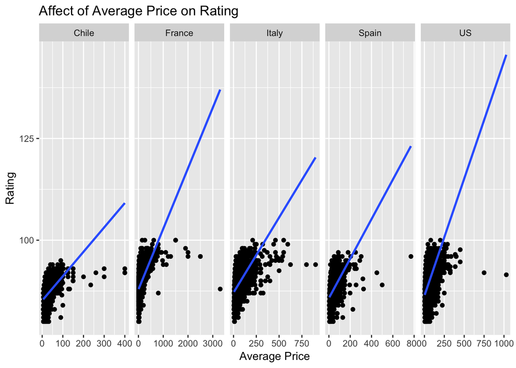

```r
winedata %>%
 filter(country %in% c("Chile","US","Spain","France","Italy")) %>%
 ggplot(aes(x=avg_price, y=avg_rating)) +
 facet_grid(. ~country, scales = "free") +
 geom_point() +
 geom_smooth(method=lm, se = FALSE) +
 ylab("Rating") +
 xlab("Average Price") +
 ggtitle("Affect of Average Price on Rating")
```

```r
winedata %>%
  ungroup() %>%
  summarize(mean_price=mean(avg_price), sd_price = sd(avg_price)) %>%
  slice(rep(1, 4)) %>%
  mutate(multiplier = c(-2, -1.5, 1.5, 2)) %>%
  mutate(outlier_limit = mean_price + multiplier * sd_price)
```

```
## # A tibble: 4 x 4
##   mean_price sd_price multiplier outlier_limit
##        <dbl>    <dbl>      <dbl>         <dbl>
## 1       34.1     41.1       -2           -48.1
## 2       34.1     41.1       -1.5         -27.5
## 3       34.1     41.1        1.5          95.8
## 4       34.1     41.1        2           116.
```

```r
winedata <- winedata %>%
  filter(avg_price <= 157)
```

We now repeat the operation we did above but with our filtered dataset with outlier prices removed.

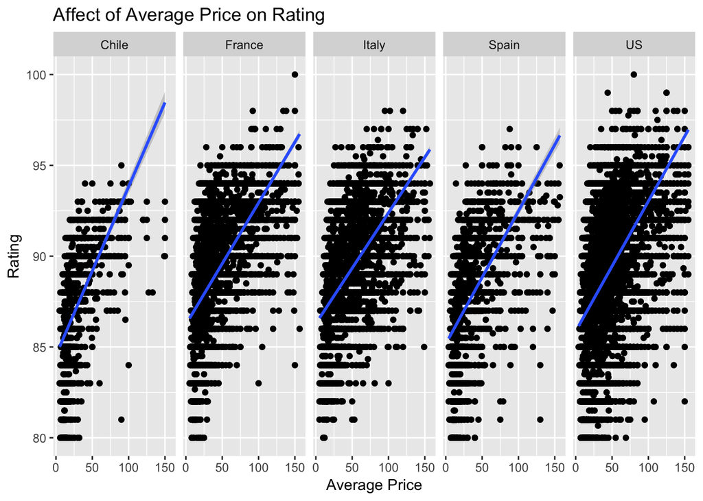

```r
winedata %>%
 filter(country %in% c("Chile","US","Spain","France","Italy")) %>%
 ggplot(aes(x=avg_price, y=avg_rating)) +
 facet_grid(. ~country) +
 geom_point() +
 geom_smooth(method=lm) +
 ylab("Rating") +
 xlab("Average Price") +
 ggtitle("Affect of Average Price on Rating")
```

Based on the previous graphs, we became suspicious of a significant relationship between rating, price, and country. We now hypothesize that there is a linear relationship between the interaction of price and country on the outcome of rating. When doing hypothesis testing we first assume the null hypothesis that there is no relationship. We will now observe the interaction between these two predictors in our linear model that shall predict rating. In order to do this we must use the broom package! For more information about this very powerful package please visit https://cran.r-project.org/web/packages/broom/vignettes/broom.html. We use tidy() from the broom package to get nice summary statistics. If we have low p values, we can reject the null hypothesis of no relationship.

```r
library(broom)

winedata = ungroup(winedata)
filter_winedata <- winedata %>%
  filter(country %in% c("Chile","US","Spain","France","Italy"))
fit <- lm(avg_rating~avg_price*country, data=filter_winedata)
fit <- fit %>%
  tidy()
fit
```

```
## # A tibble: 10 x 5
##    term                    estimate std.error statistic   p.value
##    <chr>                      <dbl>     <dbl>     <dbl>     <dbl>
##  1 (Intercept)              84.5      0.0652    1297.   0.
##  2 avg_price                 0.0928   0.00257     36.0  7.15e-282
##  3 countryFrance             1.70     0.0746      22.8  2.89e-114
##  4 countryItaly              1.74     0.0761      22.9  1.59e-115
##  5 countrySpain              0.627    0.0851       7.37 1.72e- 13
##  6 countryUS                 1.32     0.0693      19.1  6.63e- 81
##  7 avg_price:countryFrance  -0.0258   0.00273     -9.47 2.98e- 21
##  8 avg_price:countryItaly   -0.0317   0.00273    -11.6  3.09e- 31
##  9 avg_price:countrySpain   -0.0197   0.00304     -6.48 9.49e- 11
## 10 avg_price:countryUS      -0.0212   0.00264     -8.03 9.88e- 16
```

We can see that out p values are all very low, this means that all parameters are statistically significant. This is really exciting! Now lets see on average how much wine rating increases per dollar for each country. Below we extract the values from the table. All the values are relative to our baseline parameter which happens to be Chile in this case. Out of these five top wine producing countries, Chile gives you the most additional rating increase for each additonal dollar spent.

```r
Chile <- as.numeric(fit[fit$term=="avg_price", 2])
France <- as.numeric(fit[fit$term=="avg_price", 2] + fit[fit$term=="avg_price:countryFrance", 2])
Italy <- as.numeric(fit[fit$term=="avg_price", 2] + fit[fit$term=="avg_price:countryItaly", 2])
Spain <- as.numeric(fit[fit$term=="avg_price", 2] + fit[fit$term=="avg_price:countrySpain", 2])
US <- as.numeric(fit[fit$term=="avg_price", 2] + fit[fit$term=="avg_price:countryUS", 2])
data.frame (
  country = c('Chile', 'France', 'Italy', 'Spain', 'US'),
  estimate = c(Chile, France, Italy, Spain, US))
```

```
##   country   estimate
## 1   Chile 0.09277537
## 2  France 0.06694332
## 3   Italy 0.06104759
## 4   Spain 0.07308096
## 5      US 0.07157604
```

As we have demonstrated with the above graphs, a picture is worth a thousand words. So lets see how valuable a map will be! Specifically, let’s make an interactive map displaying the origins of the wines in our dataset. To accomplish this task, we use the leaflet library (“https://rstudio.github.io/leaflet/shapes.html”), which allows for excellent interactive plotting in R. Depicting the countries is a little trickier however, we will need to import another third-party dataset that describes country borders. This information is available at “http://thematicmapping.org/downloads/TM_WORLD_BORDERS_SIMPL-0.3.zip” and we load it into a special object called a “Spatial Polygons Data Frame.”

```r
# Download .shp file on the web:
download.file("http://thematicmapping.org/downloads/TM_WORLD_BORDERS_SIMPL-0.3.zip" , destfile="world_shape_file.zip")
unzip("world_shape_file.zip", overwrite = FALSE)

# Read the file with the rgdal library in R
library(rgdal)
world_spdf=readOGR( dsn= getwd() , layer="TM_WORLD_BORDERS_SIMPL-0.3")
```

Now have our dataset that describes wines, and another dataset that describes countries and their locations on the map. We need to join these two together using the almighty join command! It is important to note that we join on the attribute “country”, which is shared among both datasets, in order to combine them together.

```r
#Count the number of wines from each country
wine_country = winedata %>%
  dplyr::group_by(country) %>%
  dplyr::summarize(wine_count=n())

#prepare the wine data for joining
wine_country$country = as.character(wine_country$country)
wine_country$country[wine_country$country == "US"] ="United States"

#prepare the world data for joining
world_spdf@data = dplyr::rename(world_spdf@data,country=NAME)
world_spdf@data$country = as.character(world_spdf@data$country)

#Join!
winemap = right_join(wine_country, world_spdf@data, by="country")
world_spdf@data = winemap
```

Now that we have the combined wine and world data set, we are ready to create our map! Our map will have certain characteristics: A color palette depicted the number of wines from that area, labels identifying each country on the map and displaying the number of wines from there, and a legend that clearly explains this information.

```r
pal <- colorNumeric(
  palette = "YlOrRd",
  domain = world_spdf@data$wine_count,
  na.color = "transparent"
  )

country_label=paste(world_spdf@data$country,"<br/>", "Number of wines: ", world_spdf@data$wine_count) %>%
lapply(htmltools::HTML)

# Final Map
leaflet(world_spdf) %>%
  #Tiles are how the map is displayed. We also want to limit the zoom.
  addTiles(options = tileOptions(minZoom = 2))  %>%
  #Initialize the view
  setView(lat=10,
          lng=0,
          zoom=2) %>%
  #Display the countries and make them interactive on highlight
  addPolygons(
    fillColor = ~pal(wine_count),
    stroke = FALSE,
    fillOpacity = 0.9,
    color="white",
    weight = 0.3,
    highlight = highlightOptions(weight = 5,
                                 color = "white",
                                 fillOpacity = 0.3,
                                 bringToFront = TRUE),
    label = country_label,
    labelOptions = labelOptions(style = list("font-weight" = "normal", padding = "3px 8px"),
                                textsize = "13px",
                                direction = "auto")
  ) %>%
  addLegend( pal=pal, values=~wine_count, opacity=0.9, title = "Wine count", position = "bottomleft")
```

[interactive chart not shown]

Fantastic! This map clearly and visually shows where the wines in our dataset originated from. The country with the greatest number of wines in this dataset appears to be the US, with 42472 wines! This makes sense, considering that our dataset comes from a US company. France and Italy are also huge producers of wine, as are Chile and Argentina. Other countries, such as India and China, are very minimally represented in our dataset.

Conclusion:

Whether you’re a wine drinker or a data scientist, we hope our analysis of this wine data set has proven useful and has taught you something about wine around the world and the data behind it.